# The Interview Attendance Problem

Read the data

```r
library(readr)
df_interview <- read_csv("Interview.csv")
head(df_interview)
```

| Date of Interview | Client name | Industry | Location | Position to be closed | Nature of Skillset | Interview Type | Name(Cand ID) | Gender | Candidate Current Location | Candidate Job Location | Interview Venue | Candidate Native location | Have you obtained the necessary permission to start at the required time | Hope there will be no unscheduled meetings | Can I Call you three hours before the interview and follow up on your attendance for the interview | Can I have an alternative number/ desk number. I assure you that I will not trouble you too much | Have you taken a printout of your updated resume. Have you read the JD and understood the same | Are you clear with the venue details and the landmark. | Has the call letter been shared | Expected Attendance | Observed Attendance | Marital Status | X24 | X25 | X26 | X27 | X28 |
| --- | --- | --- | --- | --- | --- | --- | --- | --- | --- | --- | --- | --- | --- | --- | --- | --- | --- | --- | --- | --- | --- | --- | --- | --- | --- | --- | --- |
| 13.02.2015 | Hospira | Pharmaceuticals | Chennai | Production- Sterile | Routine | Scheduled Walkin | Candidate 1 | Male | Chennai | Hosur | Hosur | Hosur | Yes | Yes | Yes | Yes | Yes | Yes | Yes | Yes | No | Single | NA | NA | NA | NA | NA |
| 13.02.2015 | Hospira | Pharmaceuticals | Chennai | Production- Sterile | Routine | Scheduled Walkin | Candidate 2 | Male | Chennai | Bangalore | Hosur | Trichy | Yes | Yes | Yes | Yes | Yes | Yes | Yes | Yes | No | Single | NA | NA | NA | NA | NA |
| 13.02.2015 | Hospira | Pharmaceuticals | Chennai | Production- Sterile | Routine | Scheduled Walkin | Candidate 3 | Male | Chennai | Chennai | Hosur | Chennai | NA | Na | NA | NA | NA | NA | NA | Uncertain | No | Single | NA | NA | NA | NA | NA |
| 13.02.2015 | Hospira | Pharmaceuticals | Chennai | Production- Sterile | Routine | Scheduled Walkin | Candidate 4 | Male | Chennai | Chennai | Hosur | Chennai | Yes | Yes | No | Yes | No | Yes | Yes | Uncertain | No | Single | NA | NA | NA | NA | NA |
| 13.02.2015 | Hospira | Pharmaceuticals | Chennai | Production- Sterile | Routine | Scheduled Walkin | Candidate 5 | Male | Chennai | Bangalore | Hosur | Chennai | Yes | Yes | Yes | No | Yes | Yes | Yes | Uncertain | No | Married | NA | NA | NA | NA | NA |
| 13.02.2015 | Aon Hewitt | IT Services | Gurgaon | Selenium testing | Routine | Scheduled Walkin | Candidate 6 | Male | Gurgaon | Gurgaon | Gurgaon | Gurgaon | Yes | Yes | Yes | Yes | Yes | Yes | Yes | Yes | Yes | Single | NA | NA | NA | NA | NA |

```r
dim(df_interview)
```

```
[1] 1234   28
```

It can be seen that there are NA values in many columns and last 5 columns are empty. So let’s get rid of them first.

```r
df_interview <- subset(df_interview, select = -c(X24, X25, X26, X27, X28))
head(df_interview)
```

| Date of Interview | Client name | Industry | Location | Position to be closed | Nature of Skillset | Interview Type | Name(Cand ID) | Gender | Candidate Current Location | Candidate Job Location | Interview Venue | Candidate Native location | Have you obtained the necessary permission to start at the required time | Hope there will be no unscheduled meetings | Can I Call you three hours before the interview and follow up on your attendance for the interview | Can I have an alternative number/ desk number. I assure you that I will not trouble you too much | Have you taken a printout of your updated resume. Have you read the JD and understood the same | Are you clear with the venue details and the landmark. | Has the call letter been shared | Expected Attendance | Observed Attendance | Marital Status |
| --- | --- | --- | --- | --- | --- | --- | --- | --- | --- | --- | --- | --- | --- | --- | --- | --- | --- | --- | --- | --- | --- | --- |
| 13.02.2015 | Hospira | Pharmaceuticals | Chennai | Production- Sterile | Routine | Scheduled Walkin | Candidate 1 | Male | Chennai | Hosur | Hosur | Hosur | Yes | Yes | Yes | Yes | Yes | Yes | Yes | Yes | No | Single |
| 13.02.2015 | Hospira | Pharmaceuticals | Chennai | Production- Sterile | Routine | Scheduled Walkin | Candidate 2 | Male | Chennai | Bangalore | Hosur | Trichy | Yes | Yes | Yes | Yes | Yes | Yes | Yes | Yes | No | Single |
| 13.02.2015 | Hospira | Pharmaceuticals | Chennai | Production- Sterile | Routine | Scheduled Walkin | Candidate 3 | Male | Chennai | Chennai | Hosur | Chennai | NA | Na | NA | NA | NA | NA | NA | Uncertain | No | Single |
| 13.02.2015 | Hospira | Pharmaceuticals | Chennai | Production- Sterile | Routine | Scheduled Walkin | Candidate 4 | Male | Chennai | Chennai | Hosur | Chennai | Yes | Yes | No | Yes | No | Yes | Yes | Uncertain | No | Single |
| 13.02.2015 | Hospira | Pharmaceuticals | Chennai | Production- Sterile | Routine | Scheduled Walkin | Candidate 5 | Male | Chennai | Bangalore | Hosur | Chennai | Yes | Yes | Yes | No | Yes | Yes | Yes | Uncertain | No | Married |
| 13.02.2015 | Aon Hewitt | IT Services | Gurgaon | Selenium testing | Routine | Scheduled Walkin | Candidate 6 | Male | Gurgaon | Gurgaon | Gurgaon | Gurgaon | Yes | Yes | Yes | Yes | Yes | Yes | Yes | Yes | Yes | Single |

There are long names of columns, that can be quite difficult to handle. Let’s change the column names.

```r
colnames(df_interview)
```

```
 [1] "Date of Interview"
 [2] "Client name"
 [3] "Industry"
 [4] "Location"
 [5] "Position to be closed"
 [6] "Nature of Skillset"
 [7] "Interview Type"
 [8] "Name(Cand ID)"
 [9] "Gender"
[10] "Candidate Current Location"
[11] "Candidate Job Location"
[12] "Interview Venue"
[13] "Candidate Native location"
[14] "Have you obtained the necessary permission to start at the required time"
[15] "Hope there will be no unscheduled meetings"
[16] "Can I Call you three hours before the interview and follow up on your attendance for the interview"
[17] "Can I have an alternative number/ desk number. I assure you that I will not trouble you too much"
[18] "Have you taken a printout of your updated resume. Have you read the JD and understood the same"
[19] "Are you clear with the venue details and the landmark."
[20] "Has the call letter been shared"
[21] "Expected Attendance"
[22] "Observed Attendance"
[23] "Marital Status"
```

```r
new_col <- c("Date", "Client_name", "Industry", "Location",
             "Position", "SkillSet", "Interview_type", "Candidate_name",
             "Gender", "Current_location", "Job_location", "Venue_of_interview",
             "Candidate_native_location", "Permissions_obtained", "Unscheduled_meetings",
             "follow_up_attendance", "Alt_number", "Printout_taken", "Clear_details",
             "Call_letter", "Expected_attendance", "Observed_attendance", "Marital_status")
colnames(df_interview) <- new_col
colnames(df_interview)
```

```
 [1] "Date"                      "Client_name"               "Industry"                  "Location"
 [5] "Position"                  "SkillSet"                  "Interview_type"            "Candidate_name"
 [9] "Gender"                    "Current_location"          "Job_location"              "Venue_of_interview"
[13] "Candidate_native_location" "Permissions_obtained"      "Unscheduled_meetings"      "follow_up_attendance"
[17] "Alt_number"                "Printout_taken"            "Clear_details"             "Call_letter"
[21] "Expected_attendance"       "Observed_attendance"       "Marital_status"
```

```r
summary(df_interview)
```

```
     Date           Client_name          Industry           Location           Position           SkillSet
 Length:1234        Length:1234        Length:1234        Length:1234        Length:1234        Length:1234
 Class :character   Class :character   Class :character   Class :character   Class :character   Class :character
 Mode  :character   Mode  :character   Mode  :character   Mode  :character   Mode  :character   Mode  :character
 Interview_type     Candidate_name        Gender          Current_location   Job_location       Venue_of_interview
 Length:1234        Length:1234        Length:1234        Length:1234        Length:1234        Length:1234
 Class :character   Class :character   Class :character   Class :character   Class :character   Class :character
 Mode  :character   Mode  :character   Mode  :character   Mode  :character   Mode  :character   Mode  :character
 Candidate_native_location Permissions_obtained Unscheduled_meetings follow_up_attendance  Alt_number
 Length:1234               Length:1234          Length:1234          Length:1234          Length:1234
 Class :character          Class :character     Class :character     Class :character     Class :character
 Mode  :character          Mode  :character     Mode  :character     Mode  :character     Mode  :character
 Printout_taken     Clear_details      Call_letter        Expected_attendance Observed_attendance Marital_status
 Length:1234        Length:1234        Length:1234        Length:1234         Length:1234         Length:1234
 Class :character   Class :character   Class :character   Class :character    Class :character    Class :character
 Mode  :character   Mode  :character   Mode  :character   Mode  :character    Mode  :character    Mode  :character
```

```r
df_interview$Client_name <- sapply(df_interview$Client_name, tolower)
df_interview$Industry <- sapply(df_interview$Industry, tolower)
df_interview$Location <- sapply(df_interview$Location, tolower)
df_interview$Position <- sapply(df_interview$Position, tolower)
df_interview$SkillSet <- sapply(df_interview$SkillSet, tolower)
df_interview$Interview_type <- sapply(df_interview$Interview_type, tolower)
df_interview$Candidate_name <- sapply(df_interview$Candidate_name, tolower)
df_interview$Gender <- sapply(df_interview$Gender, tolower)
df_interview$Current_location <- sapply(df_interview$Current_location, tolower)
df_interview$Job_location <- sapply(df_interview$Job_location, tolower)
df_interview$Venue_of_interview <- sapply(df_interview$Venue_of_interview, tolower)
df_interview$Candidate_native_location <- sapply(df_interview$Candidate_native_location, tolower)
df_interview$Permissions_obtained <- sapply(df_interview$Permissions_obtained, tolower)
df_interview$Unscheduled_meetings <- sapply(df_interview$Unscheduled_meetings, tolower)
df_interview$follow_up_attendance <- sapply(df_interview$follow_up_attendance, tolower)
df_interview$Alt_number <- sapply(df_interview$Alt_number, tolower)
df_interview$Printout_taken <- sapply(df_interview$Printout_taken, tolower)
df_interview$Clear_details <- sapply(df_interview$Clear_details, tolower)
df_interview$Call_letter <- sapply(df_interview$Call_letter, tolower)
df_interview$Expected_attendance <- sapply(df_interview$Expected_attendance, tolower)
df_interview$Observed_attendance <- sapply(df_interview$Observed_attendance, tolower)
df_interview$Marital_status <- sapply(df_interview$Marital_status, tolower)
```

# Data Cleaning

Let’s check each column for inconsistencies in the data

Let’s check Date…

```r
unique(df_interview$Date)
```

```
 [1] "13.02.2015"            "19.06.2015"            "23.06.2015"            "29.06.2015"
 [5] "25.06.2015"            "25.05.16"              "25.5.2016"             "25-05-2016"
 [9] "25.05.2016"            "25-5-2016"             "04/12/16"              "13.04.2016"
[13] "27.02.2016"            "07.05.2016"            "5.5.16"                "4.5.16"
[17] "21.4.16"               "22.4.16"               "23.4.16"               "15 Apr 16"
[21] "19 Apr 16"             "20 Apr 16"             "21-Apr -16"            "22 -Apr -16"
[25] "25 – Apr-16"    "25 Apr 16"             "18 Apr 16"             "11.5.16"
[29] "10.5.16"               "11.05.16"              "12.04.2016"            "12.04.2017"
[33] "12.04.2018"            "12.04.2019"            "12.04.2020"            "12.04.2021"
[37] "12.04.2022"            "12.04.2023"            "8.5.16"                "7.5.16"
[41] "19.03.16"              "24.05.2016"            "05/11/2016"            "26/05/2016"
[45] "10.05.2016"            "28.08.2016 & 09.00 AM" "28.08.2016 & 9.30 AM"  "28.8.2016 & 12.00 PM"
[49] "28.08.2016 & 09.30 AM" "28.8.2016 & 10.30 AM"  "28.8.2016 & 09.30 AM"  "28.8.2016 & 04.00 PM"
[53] "28.08.2016 & 11.30 AM" "28.08.2016 & 11.00 AM" "28.08.2016 & 10.30 AM" "28.8.2016 & 03.00 PM"
[57] "28.08.2016 & 10.00 AM" "28.8.2016 & 02.00 PM"  "28.8.2016 & 11.00 AM"  "13.06.2016"
[61] "02.09.2016"            "02.12.2015"            "23.02.2016"            "22.03.2016"
[65] "26.02.2016"            "06.02.2016"            "21.4.2016"             "21/04/16"
[69] "21.4.15"               "22.01.2016"            "3.6.16"                "03/06/16"
[73] "09.01.2016"            "09-01-2016"            "03.04.2015"            "13/03/2015"
[77] "17/03/2015"            "17.03.2015"            "18.03.2014"            "4.04.15"
[81] "16.04.2015"            "17.04.2015"            "9.04.2015"             "05/02/15"
[85] "30.05.2016"            "07.06.2016"            "20.08.2016"            "14.01.2016"
[89] "30.1.16"               "30.01.2016"            "30/01/16"              "30.1.2016"
[93] "30.01.16"              "30-1-2016"             "06.05.2016"            NA
```

There are different formats of the date here.

```r
library(lubridate)
df_interview$Date <- gsub("&.*", "", df_interview$Date)
df_interview$Date <- dmy(df_interview$Date)
unique(df_interview$Date)
```

```
 [1] "2015-02-13" "2015-06-19" "2015-06-23" "2015-06-29" "2015-06-25" "2016-05-25" "2016-12-04" "2016-04-13"
 [9] "2016-02-27" "2016-05-07" "2016-05-05" "2016-05-04" "2016-04-21" "2016-04-22" "2016-04-23" "2016-04-15"
[17] "2016-04-19" "2016-04-20" "2016-04-25" "2016-04-18" "2016-05-11" "2016-05-10" "2016-04-12" "2017-04-12"
[25] "2018-04-12" "2019-04-12" "2020-04-12" "2021-04-12" "2022-04-12" "2023-04-12" "2016-05-08" "2016-03-19"
[33] "2016-05-24" "2016-11-05" "2016-05-26" "2016-08-28" "2016-06-13" "2016-09-02" "2015-12-02" "2016-02-23"
[41] "2016-03-22" "2016-02-26" "2016-02-06" "2015-04-21" "2016-01-22" "2016-06-03" "2016-01-09" "2015-04-03"
[49] "2015-03-13" "2015-03-17" "2014-03-18" "2015-04-04" "2015-04-16" "2015-04-17" "2015-04-09" "2015-02-05"
[57] "2016-05-30" "2016-06-07" "2016-08-20" "2016-01-14" "2016-01-30" "2016-05-06" NA
```

Let’s check Client_name…

```r
unique(df_interview$Client_name)
```

[output not shown]

```r
df_interview$Client_name <- gsub("standard chartered bank chennai", "standard chartered bank", df_interview$Client_name)
df_interview$Client_name <- gsub("aon hewitt gurgaon", "hewitt", df_interview$Client_name)
df_interview$Client_name <- gsub("aon hewitt",  "hewitt", df_interview$Client_name)
df_interview$Client_name <- gsub("<U+FEFF><U+FEFF>", "NA", df_interview$Client_name)
unique(df_interview$Client_name)
```

```
 [1] "hospira"                 "hewitt"                  "ust"                     "standard chartered bank"
 [5] "anz"                     "pfizer"                  "astrazeneca"             "flextronics"
 [9] "prodapt"                 "williams lea"            "barclays"                "woori bank"
[13] ""
```

Let’s check Industry…

```r
unique(df_interview$Industry)
```

```
[1] "pharmaceuticals"          "it services"              "bfsi"                     "it products and services"
[5] "electronics"              "telecom"                  "it"                       NA
```

```r
df_interview$Industry <- gsub("it products and services", "it", df_interview$Industry)
df_interview$Industry <- gsub("it services", "it", df_interview$Industry)
unique(df_interview$Industry)
```

```
[1] "pharmaceuticals" "it"              "bfsi"            "electronics"     "telecom"         NA
```

Let’s check Location…

```r
unique(df_interview$Location)
```

```
[1] "chennai"   "gurgaon"   "bangalore" "hyderabad" "gurgaonr"  "delhi"     "- cochin-" "noida"     NA
```

```r
df_interview$Location <- gsub("gurgaonr", "gurgaon", df_interview$Location)
df_interview$Location <- gsub("- cochin-", "cochin", df_interview$Location)
```

```r
unique(df_interview$Location)
```

```
[1] "chennai"   "gurgaon"   "bangalore" "hyderabad" "delhi"     "cochin"    "noida"     NA
```

Let’s check Position…

```r
unique(df_interview$Position)
```

```
[1] "production- sterile" "selenium testing"    "dot net"             "aml"                 "trade finance"
[6] "routine"             "niche"               NA
```

This is okay!

Let’s check Skillset

```r
unique(df_interview$SkillSet)
```

```
 [1] "routine"                                "oracle"
 [3] "accounting operations"                  "banking operations"
 [5] "fresher"                                "aml/kyc/cdd"
 [7] "cdd kyc"                                "biosimiliars"
 [9] "ra label"                               "ra publishing"
[11] "emea"                                   "lcm -manager"
[13] "licensing – ra"                  "generic drugs – ra"
[15] "biosimilars"                            "regulatory"
[17] "analytical r & d"                       "analytical r&d"
[19] "senior software engineer-mednet"        "tech lead-mednet"
[21] "tech lead- mednet"                      "technical lead"
[23] "sr automation testing"                  "tl"
[25] "senior analyst"                         "production"
[27] "core java"                              "java j2ee"
[29] "oracle plsql"                           "java,sql"
```

[output cut: 26 more lines]

Too many unique values, have to deal with it later!

Let’s check Interview_type

```r
unique(df_interview$Interview_type)
```

```
[1] "scheduled walkin"  "scheduled"         "walkin"            "scheduled walk in" "sceduled walkin"
[6] NA
```

```r
df_interview$Interview_type <- gsub("scheduled walk in", "scheduled walkin", df_interview$Interview_type)
df_interview$Interview_type <- gsub("sceduled walkin", "scheduled walkin", df_interview$Interview_type)
unique(df_interview$Interview_type)
```

```
[1] "scheduled walkin" "scheduled"        "walkin"           NA
```

Let’s check Current Location

```r
unique(df_interview$Current_location)
```

```
[1] "chennai"   "gurgaon"   "bangalore" "hyderabad" "delhi"     "- cochin-" "noida"     NA
```

```r
df_interview$Current_location <- gsub("- cochin-", "cochin", df_interview$Current_location)
```

Let’s check job location

```r
unique(df_interview$Job_location)
```

```
[1] "hosur"         "bangalore"     "chennai"       "gurgaon"       "visakapatinam" "- cochin-"     "noida"
[8] NA
```

```r
df_interview$Job_location <- gsub("- cochin-", "cochin", df_interview$Job_location)
```

Let’s check venue of interview

```r
unique(df_interview$Venue_of_interview)
```

```
[1] "hosur"     "gurgaon"   "bangalore" "chennai"   "hyderabad" "- cochin-" "noida"     NA
```

```r
df_interview$Venue_of_interview <- gsub("- cochin-", "cochin", df_interview$Venue_of_interview)
```

Let’s check Candidate native location

```r
unique(df_interview$Candidate_native_location)
```

```
 [1] "hosur"         "trichy"        "chennai"       "gurgaon"       "noida"         "delhi /ncr"    "cochin"
 [8] "trivandrum"    "bangalore"     "coimbatore"    "salem"         "tanjore"       "hyderabad"     "mumbai"
[15] "pune"          "kolkata"       "allahabad"     "panjim"        "cuttack"       "visakapatinam" "belgaum"
[22] "patna"         "chitoor"       "anantapur"     "warangal"      "ahmedabad"     "kurnool"       "vijayawada"
[29] "vellore"       "pondicherry"   "nagercoil"     "agra"          "bhubaneshwar"  "ghaziabad"     "baddi"
[36] "tuticorin"     "tirupati"      "faizabad"      "ambur"         "chandigarh"    "mysore"        "hissar"
[43] "delhi"         "kanpur"        "lucknow"       "- cochin-"     NA
```

```r
df_interview$Candidate_native_location <- gsub("delhi /ncr", "delhi", df_interview$Candidate_native_location)
df_interview$Candidate_native_location <- gsub("- cochin-", "cochin", df_interview$Candidate_native_location)
```

Let’s check Permission obtained

```r
unique(df_interview$Permissions_obtained)
```

```
[1] "yes"            NA               "no"             "not yet"        "yet to confirm" "na"
```

```r
df_interview$Permissions_obtained <- gsub("na", NA, df_interview$Permissions_obtained)
df_interview$Permissions_obtained <- gsub("yet to confirm", "no", df_interview$Permissions_obtained)
df_interview$Permissions_obtained <- gsub("not yet", "no", df_interview$Permissions_obtained)
unique(df_interview$Permissions_obtained)
```

```
[1] "yes" NA    "no"
```

Let’s check Unscheduled meetings

```r
unique(df_interview$Unscheduled_meetings)
```

```
[1] "yes"      "na"       "no"       NA         "not sure" "cant say"
```

```r
df_interview$Unscheduled_meetings <- gsub("na", NA, df_interview$Unscheduled_meetings)
df_interview$Unscheduled_meetings <- gsub("not sure", "unsure", df_interview$Unscheduled_meetings)
df_interview$Unscheduled_meetings <- gsub("cant say", "unsure", df_interview$Unscheduled_meetings)
unique(df_interview$Unscheduled_meetings)
```

```
[1] "yes"    NA       "no"     "unsure"
```

Let’s check follow-up attendance

```r
unique(df_interview$follow_up_attendance)
```

```
[1] "yes"     NA        "no"      "no dont" "na"
```

```r
df_interview$follow_up_attendance <- gsub("na", NA, df_interview$follow_up_attendance)
df_interview$follow_up_attendance <- gsub("no dont", "no", df_interview$follow_up_attendance)
unique(df_interview$follow_up_attendance)
```

```
[1] "yes" NA    "no"
```

Let’s check Alt Number

```r
unique(df_interview$Alt_number)
```

```
[1] "yes"                       NA                          "no"                        "no i have only thi number"
[5] "na"
```

```r
df_interview$Alt_number <- gsub("na", NA, df_interview$Alt_number)
df_interview$Alt_number <- gsub("no i have only thi number", "no", df_interview$Alt_number)
unique(df_interview$Alt_number)
```

```
[1] "yes" NA    "no"
```

Let’s check Printout taken

```r
unique(df_interview$Printout_taken)
```

```
[1] "yes"                   NA                      "no"                    "no- will take it soon"
[5] "not yet"               "na"
```

```r
df_interview$Printout_taken <- gsub("na", NA, df_interview$Printout_taken)
df_interview$Printout_taken <- gsub("not yet", "no", df_interview$Printout_taken)
df_interview$Printout_taken <- gsub("no- will take it soon", "no", df_interview$Printout_taken)
unique(df_interview$Printout_taken)
```

```
[1] "yes" NA    "no"
```

Let;s check clear details

```r
unique(df_interview$Clear_details)
```

```
[1] "yes"                 NA                    "no"                  "no- i need to check" "na"
```

```r
df_interview$Clear_details <- gsub("na", NA, df_interview$Clear_details)
df_interview$Clear_details <- gsub("no- i need to check", "no", df_interview$Clear_details)
unique(df_interview$Clear_details)
```

```
[1] "yes" NA    "no"
```

Let’s check call letter

```r
unique(df_interview$Call_letter)
```

```
[1] "yes"            NA               "havent checked" "no"             "need to check"  "not sure"
[7] "yet to check"   "not yet"        "na"
```

```r
df_interview$Call_letter <- gsub("na", NA, df_interview$Call_letter)
df_interview$Call_letter <- gsub("havent checked", "unsure", df_interview$Call_letter)
df_interview$Call_letter <- gsub("need to check", "unsure", df_interview$Call_letter)
df_interview$Call_letter <- gsub("not sure", "unsure", df_interview$Call_letter)
df_interview$Call_letter <- gsub("yet to check", "unsure", df_interview$Call_letter)
df_interview$Call_letter <- gsub("not yet", "unsure", df_interview$Call_letter)
unique(df_interview$Call_letter)
```

```
[1] "yes"    NA       "unsure" "no"
```

Lets’ check expected attendance

```r
unique(df_interview$Expected_attendance)
```

```
[1] "yes"       "uncertain" "no"        NA          "11:00 am"  "10.30 am"
```

```r
df_interview$Expected_attendance <- gsub("11:00 am", "yes", df_interview$Expected_attendance)
df_interview$Expected_attendance <- gsub("10.30 am", "yes", df_interview$Expected_attendance)
unique(df_interview$Expected_attendance)
```

```
[1] "yes"       "uncertain" "no"        NA
```

Let’s check observed attendance

```r
unique(df_interview$Observed_attendance)
```

```
[1] "no"  "yes" NA
```

Let’s check marital status

```r
unique(df_interview$Marital_status)
```

```
[1] "single"  "married" NA
```

Since Skillset column has huge number of unique values and it is difficult to clean it. Let us drop it and go ahead with other columns.

```r
head(df_interview)
```

| Date | Client_name | Industry | Location | Position | SkillSet | Interview_type | Candidate_name | Gender | Current_location | Job_location | Venue_of_interview | Candidate_native_location | Permissions_obtained | Unscheduled_meetings | follow_up_attendance | Alt_number | Printout_taken | Clear_details | Call_letter | Expected_attendance | Observed_attendance | Marital_status |
| --- | --- | --- | --- | --- | --- | --- | --- | --- | --- | --- | --- | --- | --- | --- | --- | --- | --- | --- | --- | --- | --- | --- |
| 2015-02-13 | hospira | pharmaceuticals | chennai | production- sterile | routine | scheduled walkin | candidate 1 | male | chennai | hosur | hosur | hosur | yes | yes | yes | yes | yes | yes | yes | yes | no | single |
| 2015-02-13 | hospira | pharmaceuticals | chennai | production- sterile | routine | scheduled walkin | candidate 2 | male | chennai | bangalore | hosur | trichy | yes | yes | yes | yes | yes | yes | yes | yes | no | single |
| 2015-02-13 | hospira | pharmaceuticals | chennai | production- sterile | routine | scheduled walkin | candidate 3 | male | chennai | chennai | hosur | chennai | NA | NA | NA | NA | NA | NA | NA | uncertain | no | single |
| 2015-02-13 | hospira | pharmaceuticals | chennai | production- sterile | routine | scheduled walkin | candidate 4 | male | chennai | chennai | hosur | chennai | yes | yes | no | yes | no | yes | yes | uncertain | no | single |
| 2015-02-13 | hospira | pharmaceuticals | chennai | production- sterile | routine | scheduled walkin | candidate 5 | male | chennai | bangalore | hosur | chennai | yes | yes | yes | no | yes | yes | yes | uncertain | no | married |
| 2015-02-13 | hewitt | it | gurgaon | selenium testing | routine | scheduled walkin | candidate 6 | male | gurgaon | gurgaon | gurgaon | gurgaon | yes | yes | yes | yes | yes | yes | yes | yes | yes | single |

```r
dim(df_interview)
```

```
[1] 1234   23
```

Let us remove the rows with NA entries.

```r
newinterview <- na.omit(df_interview)
dim(newinterview)
```

```
[1] 965  23
```

```r
unique(newinterview$Date)
```

```
 [1] "2015-02-13" "2015-06-19" "2015-06-23" "2015-06-29" "2015-06-25" "2016-05-25" "2016-12-04" "2016-04-13"
 [9] "2016-02-27" "2016-05-07" "2016-05-05" "2016-05-04" "2016-04-21" "2016-04-22" "2016-04-23" "2016-04-15"
[17] "2016-04-19" "2016-04-20" "2016-04-25" "2016-04-18" "2016-05-11" "2016-05-10" "2017-04-12" "2018-04-12"
[25] "2019-04-12" "2020-04-12" "2022-04-12" "2016-05-08" "2016-03-19" "2016-05-24" "2016-11-05" "2016-05-26"
[33] "2016-08-28" "2016-06-13" "2016-09-02" "2015-12-02" "2016-02-23" "2016-03-22" "2016-02-26" "2016-02-06"
[41] "2016-01-22" "2016-06-03" "2016-01-09" "2015-04-21" "2015-04-03" "2015-03-13" "2015-03-17" "2014-03-18"
[49] "2015-04-04" "2015-04-16" "2015-04-17" "2015-04-09" "2015-02-05" "2016-05-30" "2016-06-07" "2016-08-20"
[57] "2016-01-14" "2016-01-30" "2016-05-06"
```

There are dates after 2018 also, and may be wrong entries. So let us omit those entries.

```r
library(dplyr)
newinterview <- newinterview %>% filter(Date < "2019-01-01")
newinterview <- newinterview[,-which(colnames(newinterview) == "SkillSet")]
unique(newinterview$Date)
```

```
 [1] "2015-02-13" "2015-06-19" "2015-06-23" "2015-06-29" "2015-06-25" "2016-05-25" "2016-12-04" "2016-04-13"
 [9] "2016-02-27" "2016-05-07" "2016-05-05" "2016-05-04" "2016-04-21" "2016-04-22" "2016-04-23" "2016-04-15"
[17] "2016-04-19" "2016-04-20" "2016-04-25" "2016-04-18" "2016-05-11" "2016-05-10" "2017-04-12" "2018-04-12"
[25] "2016-05-08" "2016-03-19" "2016-05-24" "2016-11-05" "2016-05-26" "2016-08-28" "2016-06-13" "2016-09-02"
[33] "2015-12-02" "2016-02-23" "2016-03-22" "2016-02-26" "2016-02-06" "2016-01-22" "2016-06-03" "2016-01-09"
[41] "2015-04-21" "2015-04-03" "2015-03-13" "2015-03-17" "2014-03-18" "2015-04-04" "2015-04-16" "2015-04-17"
[49] "2015-04-09" "2015-02-05" "2016-05-30" "2016-06-07" "2016-08-20" "2016-01-14" "2016-01-30" "2016-05-06"
```

```r
dim(newinterview)
```

```
[1] 962  22
```

So we have a dataset of 962 entries in 22 columns.

```r
head(newinterview)
```

| Date | Client_name | Industry | Location | Position | Interview_type | Candidate_name | Gender | Current_location | Job_location | Venue_of_interview | Candidate_native_location | Permissions_obtained | Unscheduled_meetings | follow_up_attendance | Alt_number | Printout_taken | Clear_details | Call_letter | Expected_attendance | Observed_attendance | Marital_status |
| --- | --- | --- | --- | --- | --- | --- | --- | --- | --- | --- | --- | --- | --- | --- | --- | --- | --- | --- | --- | --- | --- |
| 2015-02-13 | hospira | pharmaceuticals | chennai | production- sterile | scheduled walkin | candidate 1 | male | chennai | hosur | hosur | hosur | yes | yes | yes | yes | yes | yes | yes | yes | no | single |
| 2015-02-13 | hospira | pharmaceuticals | chennai | production- sterile | scheduled walkin | candidate 2 | male | chennai | bangalore | hosur | trichy | yes | yes | yes | yes | yes | yes | yes | yes | no | single |
| 2015-02-13 | hospira | pharmaceuticals | chennai | production- sterile | scheduled walkin | candidate 4 | male | chennai | chennai | hosur | chennai | yes | yes | no | yes | no | yes | yes | uncertain | no | single |
| 2015-02-13 | hospira | pharmaceuticals | chennai | production- sterile | scheduled walkin | candidate 5 | male | chennai | bangalore | hosur | chennai | yes | yes | yes | no | yes | yes | yes | uncertain | no | married |
| 2015-02-13 | hewitt | it | gurgaon | selenium testing | scheduled walkin | candidate 6 | male | gurgaon | gurgaon | gurgaon | gurgaon | yes | yes | yes | yes | yes | yes | yes | yes | yes | single |
| 2015-02-13 | hewitt | it | gurgaon | selenium testing | scheduled walkin | candidate 7 | male | gurgaon | gurgaon | gurgaon | gurgaon | yes | yes | yes | yes | yes | yes | yes | yes | yes | single |

Split date into day, month, year and weekday

```r
newinterview$Year <- year(newinterview$Date)
newinterview$Month <- month(newinterview$Date)
newinterview$Day <- day(newinterview$Date)
newinterview$weekday <- wday(newinterview$Date)
newinterview <- newinterview[,-which(colnames(newinterview) == "Date")]
```

```r
head(newinterview)
```

| Client_name | Industry | Location | Position | Interview_type | Candidate_name | Gender | Current_location | Job_location | Venue_of_interview | Candidate_native_location | Permissions_obtained | Unscheduled_meetings | follow_up_attendance | Alt_number | Printout_taken | Clear_details | Call_letter | Expected_attendance | Observed_attendance | Marital_status | Year | Month | Day | weekday |
| --- | --- | --- | --- | --- | --- | --- | --- | --- | --- | --- | --- | --- | --- | --- | --- | --- | --- | --- | --- | --- | --- | --- | --- | --- |
| hospira | pharmaceuticals | chennai | production- sterile | scheduled walkin | candidate 1 | male | chennai | hosur | hosur | hosur | yes | yes | yes | yes | yes | yes | yes | yes | no | single | 2015 | 2 | 13 | 6 |
| hospira | pharmaceuticals | chennai | production- sterile | scheduled walkin | candidate 2 | male | chennai | bangalore | hosur | trichy | yes | yes | yes | yes | yes | yes | yes | yes | no | single | 2015 | 2 | 13 | 6 |
| hospira | pharmaceuticals | chennai | production- sterile | scheduled walkin | candidate 4 | male | chennai | chennai | hosur | chennai | yes | yes | no | yes | no | yes | yes | uncertain | no | single | 2015 | 2 | 13 | 6 |
| hospira | pharmaceuticals | chennai | production- sterile | scheduled walkin | candidate 5 | male | chennai | bangalore | hosur | chennai | yes | yes | yes | no | yes | yes | yes | uncertain | no | married | 2015 | 2 | 13 | 6 |
| hewitt | it | gurgaon | selenium testing | scheduled walkin | candidate 6 | male | gurgaon | gurgaon | gurgaon | gurgaon | yes | yes | yes | yes | yes | yes | yes | yes | yes | single | 2015 | 2 | 13 | 6 |
| hewitt | it | gurgaon | selenium testing | scheduled walkin | candidate 7 | male | gurgaon | gurgaon | gurgaon | gurgaon | yes | yes | yes | yes | yes | yes | yes | yes | yes | single | 2015 | 2 | 13 | 6 |

```r
glimpse(newinterview)
```

```
Observations: 962
Variables: 25
$ Client_name               <chr> "hospira", "hospira", "hospira", "hospira", "hewitt", "hewitt", "hewitt", "hewi...
$ Industry                  <chr> "pharmaceuticals", "pharmaceuticals", "pharmaceuticals", "pharmaceuticals", "it...
$ Location                  <chr> "chennai", "chennai", "chennai", "chennai", "gurgaon", "gurgaon", "gurgaon", "g...
$ Position                  <chr> "production- sterile", "production- sterile", "production- sterile", "productio...
$ Interview_type            <chr> "scheduled walkin", "scheduled walkin", "scheduled walkin", "scheduled walkin",...
$ Candidate_name            <chr> "candidate 1", "candidate 2", "candidate 4", "candidate 5", "candidate 6", "can...
$ Gender                    <chr> "male", "male", "male", "male", "male", "male", "female", "male", "female", "ma...
$ Current_location          <chr> "chennai", "chennai", "chennai", "chennai", "gurgaon", "gurgaon", "gurgaon", "g...
$ Job_location              <chr> "hosur", "bangalore", "chennai", "bangalore", "gurgaon", "gurgaon", "gurgaon", ...
$ Venue_of_interview        <chr> "hosur", "hosur", "hosur", "hosur", "gurgaon", "gurgaon", "gurgaon", "gurgaon",...
$ Candidate_native_location <chr> "hosur", "trichy", "chennai", "chennai", "gurgaon", "gurgaon", "noida", "delhi"...
$ Permissions_obtained      <chr> "yes", "yes", "yes", "yes", "yes", "yes", "yes", "yes", "yes", "yes", "no", "ye...
$ Unscheduled_meetings      <chr> "yes", "yes", "yes", "yes", "yes", "yes", "yes", "yes", "yes", "yes", "yes", "y...
$ follow_up_attendance      <chr> "yes", "yes", "no", "yes", "yes", "yes", "yes", "yes", "yes", "yes", "no", "yes...
$ Alt_number                <chr> "yes", "yes", "yes", "no", "yes", "yes", "yes", "yes", "yes", "yes", "no", "yes...
$ Printout_taken            <chr> "yes", "yes", "no", "yes", "yes", "yes", "yes", "yes", "yes", "yes", "yes", "ye...
$ Clear_details             <chr> "yes", "yes", "yes", "yes", "yes", "yes", "yes", "yes", "yes", "yes", "yes", "y...
$ Call_letter               <chr> "yes", "yes", "yes", "yes", "yes", "yes", "yes", "yes", "yes", "yes", "yes", "y...
$ Expected_attendance       <chr> "yes", "yes", "uncertain", "uncertain", "yes", "yes", "yes", "yes", "yes", "yes...
$ Observed_attendance       <chr> "no", "no", "no", "no", "yes", "yes", "yes", "yes", "no", "yes", "no", "yes", "...
$ Marital_status            <chr> "single", "single", "single", "married", "single", "single", "single", "single"...
$ Year                      <dbl> 2015, 2015, 2015, 2015, 2015, 2015, 2015, 2015, 2015, 2015, 2015, 2015, 2015, 2...
$ Month                     <dbl> 2, 2, 2, 2, 2, 2, 2, 2, 2, 6, 6, 6, 6, 6, 6, 6, 6, 6, 6, 6, 6, 6, 6, 6, 6, 6, 6...
$ Day                       <int> 13, 13, 13, 13, 13, 13, 13, 13, 13, 19, 19, 19, 19, 19, 19, 19, 19, 19, 19, 19,...
$ weekday                   <dbl> 6, 6, 6, 6, 6, 6, 6, 6, 6, 6, 6, 6, 6, 6, 6, 6, 6, 6, 6, 6, 6, 6, 6, 6, 6, 6, 6...
```

Convert character columns to factors

```r
character_vars <- lapply(newinterview, class) == "character"
newinterview[, character_vars] <- lapply(newinterview[, character_vars], as.factor)
glimpse(newinterview)
```

```
Observations: 962
Variables: 25
$ Client_name               <fctr> hospira, hospira, hospira, hospira, hewitt, hewitt, hewitt, hewitt, hewitt, us...
$ Industry                  <fctr> pharmaceuticals, pharmaceuticals, pharmaceuticals, pharmaceuticals, it, it, it...
$ Location                  <fctr> chennai, chennai, chennai, chennai, gurgaon, gurgaon, gurgaon, gurgaon, gurgao...
$ Position                  <fctr> production- sterile, production- sterile, production- sterile, production- ste...
$ Interview_type            <fctr> scheduled walkin, scheduled walkin, scheduled walkin, scheduled walkin, schedu...
$ Candidate_name            <fctr> candidate 1, candidate 2, candidate 4, candidate 5, candidate 6, candidate 7, ...
$ Gender                    <fctr> male, male, male, male, male, male, female, male, female, male, female, male, ...
$ Current_location          <fctr> chennai, chennai, chennai, chennai, gurgaon, gurgaon, gurgaon, gurgaon, gurgao...
$ Job_location              <fctr> hosur, bangalore, chennai, bangalore, gurgaon, gurgaon, gurgaon, gurgaon, gurg...
$ Venue_of_interview        <fctr> hosur, hosur, hosur, hosur, gurgaon, gurgaon, gurgaon, gurgaon, gurgaon, banga...
$ Candidate_native_location <fctr> hosur, trichy, chennai, chennai, gurgaon, gurgaon, noida, delhi, delhi, cochin...
$ Permissions_obtained      <fctr> yes, yes, yes, yes, yes, yes, yes, yes, yes, yes, no, yes, no, yes, yes, yes, ...
$ Unscheduled_meetings      <fctr> yes, yes, yes, yes, yes, yes, yes, yes, yes, yes, yes, yes, yes, yes, yes, yes...
$ follow_up_attendance      <fctr> yes, yes, no, yes, yes, yes, yes, yes, yes, yes, no, yes, yes, yes, yes, yes, ...
$ Alt_number                <fctr> yes, yes, yes, no, yes, yes, yes, yes, yes, yes, no, yes, yes, yes, yes, yes, ...
$ Printout_taken            <fctr> yes, yes, no, yes, yes, yes, yes, yes, yes, yes, yes, yes, yes, yes, yes, yes,...
$ Clear_details             <fctr> yes, yes, yes, yes, yes, yes, yes, yes, yes, yes, yes, yes, yes, yes, yes, yes...
$ Call_letter               <fctr> yes, yes, yes, yes, yes, yes, yes, yes, yes, yes, yes, yes, unsure, yes, yes, ...
$ Expected_attendance       <fctr> yes, yes, uncertain, uncertain, yes, yes, yes, yes, yes, yes, uncertain, yes, ...
$ Observed_attendance       <fctr> no, no, no, no, yes, yes, yes, yes, no, yes, no, yes, yes, yes, yes, yes, no, ...
$ Marital_status            <fctr> single, single, single, married, single, single, single, single, single, singl...
$ Year                      <dbl> 2015, 2015, 2015, 2015, 2015, 2015, 2015, 2015, 2015, 2015, 2015, 2015, 2015, 2...
$ Month                     <dbl> 2, 2, 2, 2, 2, 2, 2, 2, 2, 6, 6, 6, 6, 6, 6, 6, 6, 6, 6, 6, 6, 6, 6, 6, 6, 6, 6...
$ Day                       <int> 13, 13, 13, 13, 13, 13, 13, 13, 13, 19, 19, 19, 19, 19, 19, 19, 19, 19, 19, 19,...
$ weekday                   <dbl> 6, 6, 6, 6, 6, 6, 6, 6, 6, 6, 6, 6, 6, 6, 6, 6, 6, 6, 6, 6, 6, 6, 6, 6, 6, 6, 6...
```

“Observed_attendance” is what we need to predict here. Let us convert factor to numeric.

```r
df <- newinterview
character_vars <- lapply(df, class) == "factor"
df[, character_vars] <- lapply(df[, character_vars], as.numeric)
head(df)
```

| Client_name | Industry | Location | Position | Interview_type | Candidate_name | Gender | Current_location | Job_location | Venue_of_interview | Candidate_native_location | Permissions_obtained | Unscheduled_meetings | follow_up_attendance | Alt_number | Printout_taken | Clear_details | Call_letter | Expected_attendance | Observed_attendance | Marital_status | Year | Month | Day | weekday |
| --- | --- | --- | --- | --- | --- | --- | --- | --- | --- | --- | --- | --- | --- | --- | --- | --- | --- | --- | --- | --- | --- | --- | --- | --- |
| 6 | 4 | 2 | 4 | 2 | 1 | 2 | 2 | 5 | 5 | 16 | 2 | 3 | 2 | 2 | 2 | 2 | 3 | 3 | 1 | 2 | 2015 | 2 | 13 | 6 |
| 6 | 4 | 2 | 4 | 2 | 318 | 2 | 2 | 1 | 5 | 32 | 2 | 3 | 2 | 2 | 2 | 2 | 3 | 3 | 1 | 2 | 2015 | 2 | 13 | 6 |
| 6 | 4 | 2 | 4 | 2 | 468 | 2 | 2 | 2 | 5 | 8 | 2 | 3 | 1 | 2 | 1 | 2 | 3 | 2 | 1 | 2 | 2015 | 2 | 13 | 6 |
| 6 | 4 | 2 | 4 | 2 | 542 | 2 | 2 | 1 | 5 | 8 | 2 | 3 | 2 | 1 | 2 | 2 | 3 | 2 | 1 | 1 | 2015 | 2 | 13 | 6 |
| 5 | 3 | 5 | 6 | 2 | 613 | 2 | 5 | 4 | 4 | 14 | 2 | 3 | 2 | 2 | 2 | 2 | 3 | 3 | 2 | 2 | 2015 | 2 | 13 | 6 |
| 5 | 3 | 5 | 6 | 2 | 679 | 2 | 5 | 4 | 4 | 14 | 2 | 3 | 2 | 2 | 2 | 2 | 3 | 3 | 2 | 2 | 2015 | 2 | 13 | 6 |

```r
glimpse(df)
```

```
Observations: 962
Variables: 25
$ Client_name               <dbl> 6, 6, 6, 6, 5, 5, 5, 5, 5, 10, 10, 10, 10, 10, 10, 10, 10, 10, 10, 10, 10, 10, ...
$ Industry                  <dbl> 4, 4, 4, 4, 3, 3, 3, 3, 3, 3, 3, 3, 3, 3, 3, 3, 3, 3, 3, 3, 3, 3, 3, 3, 3, 3, 3...
$ Location                  <dbl> 2, 2, 2, 2, 5, 5, 5, 5, 5, 1, 1, 1, 1, 1, 1, 1, 1, 1, 1, 1, 1, 1, 1, 1, 1, 1, 1...
$ Position                  <dbl> 4, 4, 4, 4, 6, 6, 6, 6, 6, 2, 2, 2, 2, 2, 2, 2, 2, 2, 2, 2, 2, 2, 2, 2, 2, 2, 2...
$ Interview_type            <dbl> 2, 2, 2, 2, 2, 2, 2, 2, 2, 2, 2, 2, 2, 2, 2, 2, 2, 2, 2, 2, 2, 2, 2, 2, 2, 2, 2...
$ Candidate_name            <dbl> 1, 318, 468, 542, 613, 679, 785, 866, 2, 87, 198, 241, 252, 263, 274, 285, 296,...
$ Gender                    <dbl> 2, 2, 2, 2, 2, 2, 1, 2, 1, 2, 1, 2, 2, 2, 1, 1, 1, 2, 2, 2, 2, 2, 2, 2, 2, 2, 2...
$ Current_location          <dbl> 2, 2, 2, 2, 5, 5, 5, 5, 5, 1, 1, 1, 1, 1, 1, 1, 1, 1, 1, 1, 1, 1, 1, 1, 1, 1, 1...
$ Job_location              <dbl> 5, 1, 2, 1, 4, 4, 4, 4, 4, 1, 1, 1, 1, 1, 1, 1, 1, 1, 1, 1, 1, 1, 1, 1, 1, 1, 1...
$ Venue_of_interview        <dbl> 5, 5, 5, 5, 4, 4, 4, 4, 4, 1, 1, 1, 1, 1, 1, 1, 1, 1, 1, 1, 1, 1, 1, 1, 1, 1, 1...
$ Candidate_native_location <dbl> 16, 32, 8, 8, 14, 14, 25, 13, 13, 10, 33, 6, 33, 10, 10, 33, 6, 10, 10, 33, 33,...
$ Permissions_obtained      <dbl> 2, 2, 2, 2, 2, 2, 2, 2, 2, 2, 1, 2, 1, 2, 2, 2, 1, 2, 2, 1, 2, 2, 2, 2, 1, 1, 1...
$ Unscheduled_meetings      <dbl> 3, 3, 3, 3, 3, 3, 3, 3, 3, 3, 3, 3, 3, 3, 3, 3, 3, 3, 3, 3, 3, 3, 3, 3, 1, 3, 3...
$ follow_up_attendance      <dbl> 2, 2, 1, 2, 2, 2, 2, 2, 2, 2, 1, 2, 2, 2, 2, 2, 2, 2, 2, 2, 2, 2, 2, 2, 2, 2, 2...
$ Alt_number                <dbl> 2, 2, 2, 1, 2, 2, 2, 2, 2, 2, 1, 2, 2, 2, 2, 2, 1, 2, 2, 2, 2, 2, 2, 1, 2, 2, 2...
$ Printout_taken            <dbl> 2, 2, 1, 2, 2, 2, 2, 2, 2, 2, 2, 2, 2, 2, 2, 2, 2, 2, 2, 2, 2, 2, 2, 1, 2, 2, 1...
$ Clear_details             <dbl> 2, 2, 2, 2, 2, 2, 2, 2, 2, 2, 2, 2, 2, 2, 2, 2, 2, 2, 2, 2, 2, 2, 2, 2, 2, 2, 2...
$ Call_letter               <dbl> 3, 3, 3, 3, 3, 3, 3, 3, 3, 3, 3, 3, 2, 3, 3, 3, 3, 3, 3, 1, 3, 3, 3, 3, 1, 1, 1...
$ Expected_attendance       <dbl> 3, 3, 2, 2, 3, 3, 3, 3, 3, 3, 2, 3, 2, 3, 3, 3, 1, 3, 3, 1, 3, 3, 3, 2, 1, 1, 1...
$ Observed_attendance       <dbl> 1, 1, 1, 1, 2, 2, 2, 2, 1, 2, 1, 2, 2, 2, 2, 2, 1, 2, 1, 1, 2, 2, 2, 1, 1, 1, 1...
$ Marital_status            <dbl> 2, 2, 2, 1, 2, 2, 2, 2, 2, 2, 2, 2, 2, 2, 2, 2, 2, 2, 2, 2, 2, 2, 2, 2, 2, 1, 2...
$ Year                      <dbl> 2015, 2015, 2015, 2015, 2015, 2015, 2015, 2015, 2015, 2015, 2015, 2015, 2015, 2...
$ Month                     <dbl> 2, 2, 2, 2, 2, 2, 2, 2, 2, 6, 6, 6, 6, 6, 6, 6, 6, 6, 6, 6, 6, 6, 6, 6, 6, 6, 6...
$ Day                       <int> 13, 13, 13, 13, 13, 13, 13, 13, 13, 19, 19, 19, 19, 19, 19, 19, 19, 19, 19, 19,...
$ weekday                   <dbl> 6, 6, 6, 6, 6, 6, 6, 6, 6, 6, 6, 6, 6, 6, 6, 6, 6, 6, 6, 6, 6, 6, 6, 6, 6, 6, 6...
```

```r
factor_cols = c("Client_name", "Industry", "Location",
             "Position", "Interview_type", "Candidate_name",
             "Gender", "Current_location", "Job_location", "Venue_of_interview",
             "Candidate_native_location", "Permissions_obtained", "Unscheduled_meetings",
             "follow_up_attendance", "Alt_number", "Printout_taken", "Clear_details",
             "Call_letter", "Expected_attendance", "Observed_attendance", "Marital_status")
```

Find the baseline of Prediction.

```r
as.data.frame(table(newinterview$Observed_attendance))
```

| Var1 | Freq |
| --- | --- |
| no | 292 |
| yes | 670 |

```r
baseline = (670 / (670 + 292))
baseline
```

```
[1] 0.6964657
```

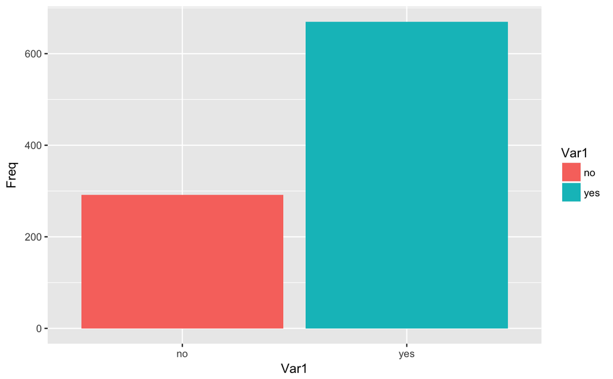

```r
library(ggplot2)
ggplot(data = as.data.frame(table(newinterview$Observed_attendance)), aes(Var1, Freq, fill=Var1)) +
  geom_bar(position = "dodge", stat = "identity")
```

Almost 70% of the entries in Observed attendance is “Yes”. So the baseline prediction is 70% Yes. We have to make the prediction models having accuracy more than the baseline accuracy.